# ALWC_Game1

Toronto Blue Jays played against the Minnesota Twins in the American League Wildcard Series. The first game of the series was played on October 3rd when the Twins beat the Blue Jays by a score of 3-1. As a baseball fan, I wanted to statistically analyze and visualize certain aspects of this game. Rather than predictive modelling, this project simply focuses on the postgame analysis of the first game of the American League Wildcard Series.

```python
import pandas as pd
import numpy as np
import matplotlib.pyplot as plt
import seaborn as sns
import pybaseball

pd.set_option('display.max_columns', None)
```

```python
#Blue Jays Offense Data from the Match
jays = pybaseball.statcast(start_dt = "2023-10-03", team = "MIN")
jays["batter"] = jays["batter"].astype('category')
jays.head()
```

```
This is a large query, it may take a moment to complete
```

|  | pitch_type | game_date | release_speed | release_pos_x | release_pos_z | player_name | batter | pitcher | events | description | spin_dir | spin_rate_deprecated | break_angle_deprecated | break_length_deprecated | zone | des | game_type | stand | p_throws | home_team | away_team | type | hit_location | bb_type | balls | strikes | game_year | pfx_x | pfx_z | … |
| --- | --- | --- | --- | --- | --- | --- | --- | --- | --- | --- | --- | --- | --- | --- | --- | --- | --- | --- | --- | --- | --- | --- | --- | --- | --- | --- | --- | --- | --- | --- |
| 80 | FF | 2023-10-03 | 100.9 | -2.12 | 6.1 | Duran, Jhoan | 543807 | 661395 | field_out | hit_into_play | <NA> | <NA> | <NA> | <NA> | 5 | George Springer grounds out sharply, first bas... | F | R | R | MIN | TOR | X | 3 | ground_ball | 0 | 0 | 2023 | -0.94 | 0.76 | … |
| 81 | FF | 2023-10-03 | 102.5 | -2.02 | 6.02 | Duran, Jhoan | 593160 | 661395 | walk | ball | <NA> | <NA> | <NA> | <NA> | 11 | Whit Merrifield walks. | F | R | R | MIN | TOR | B | <NA> | NaN | 3 | 2 | 2023 | -1.0 | 1.05 | … |
| 84 | CU | 2023-10-03 | 89.7 | -2.06 | 5.91 | Duran, Jhoan | 593160 | 661395 | NaN | ball | <NA> | <NA> | <NA> | <NA> | 14 | Whit Merrifield walks. | F | R | R | MIN | TOR | B | <NA> | NaN | 2 | 2 | 2023 | 0.27 | -0.62 | … |
| 86 | FF | 2023-10-03 | 102.0 | -1.77 | 6.04 | Duran, Jhoan | 593160 | 661395 | NaN | ball | <NA> | <NA> | <NA> | <NA> | 11 | Whit Merrifield walks. | F | R | R | MIN | TOR | B | <NA> | NaN | 1 | 2 | 2023 | -0.97 | 1.04 | … |
| 88 | FF | 2023-10-03 | 101.8 | -1.93 | 5.96 | Duran, Jhoan | 593160 | 661395 | NaN | foul | <NA> | <NA> | <NA> | <NA> | 6 | Whit Merrifield walks. | F | R | R | MIN | TOR | S | <NA> | NaN | 1 | 1 | 2023 | -0.92 | 1.17 | … |

```python
#Twins Offense Data from the Match
twins = pybaseball.statcast(start_dt = "2023-10-03", team = "TOR")
twins["batter"] = twins["batter"].astype('category')
twins.head()
```

```
This is a large query, it may take a moment to complete
```

|  | pitch_type | game_date | release_speed | release_pos_x | release_pos_z | player_name | batter | pitcher | events | description | spin_dir | spin_rate_deprecated | break_angle_deprecated | break_length_deprecated | zone | des | game_type | stand | p_throws | home_team | away_team | type | hit_location | bb_type | balls | strikes | game_year | pfx_x | pfx_z | … |
| --- | --- | --- | --- | --- | --- | --- | --- | --- | --- | --- | --- | --- | --- | --- | --- | --- | --- | --- | --- | --- | --- | --- | --- | --- | --- | --- | --- | --- | --- | --- |
| 48 | ST | 2023-10-03 | 87.1 | -2.02 | 5.62 | Hicks, Jordan | 650489 | 663855 | strikeout | called_strike | <NA> | <NA> | <NA> | <NA> | 4 | Willi Castro called out on strikes. | F | L | R | MIN | TOR | S | 2 | NaN | 2 | 2 | 2023 | 1.11 | 0.07 | … |
| 51 | FF | 2023-10-03 | 100.6 | -1.56 | 5.96 | Hicks, Jordan | 650489 | 663855 | NaN | ball | <NA> | <NA> | <NA> | <NA> | 14 | Willi Castro called out on strikes. | F | L | R | MIN | TOR | B | <NA> | NaN | 1 | 2 | 2023 | -0.71 | 1.28 | … |
| 53 | FF | 2023-10-03 | 101.5 | -1.75 | 5.97 | Hicks, Jordan | 650489 | 663855 | NaN | ball | <NA> | <NA> | <NA> | <NA> | 12 | Willi Castro called out on strikes. | F | L | R | MIN | TOR | B | <NA> | NaN | 0 | 2 | 2023 | -0.55 | 1.3 | … |
| 55 | SI | 2023-10-03 | 101.4 | -1.72 | 5.97 | Hicks, Jordan | 650489 | 663855 | NaN | swinging_strike | <NA> | <NA> | <NA> | <NA> | 14 | Willi Castro called out on strikes. | F | L | R | MIN | TOR | S | <NA> | NaN | 0 | 1 | 2023 | -1.19 | 0.52 | … |
| 57 | SI | 2023-10-03 | 102.4 | -1.73 | 5.84 | Hicks, Jordan | 650489 | 663855 | NaN | called_strike | <NA> | <NA> | <NA> | <NA> | 8 | Willi Castro called out on strikes. | F | L | R | MIN | TOR | S | <NA> | NaN | 0 | 0 | 2023 | -1.17 | 0.63 | … |

# Plate Discipline

One thing that really impressed me during the game was the plate discipline shown by the Minnesota Twins hitters (and rookies). Blue Jays pitcher Kevin Gausman gave away 3 walks during the game. While this on its own might not seem high, it is interesting when you realise that he gave away 3 walks in 4 innings in this game (0.75 walks/innings pitched), whereas during the regular season, he had given just 55 walks in 185 innings pitched (0.3 walks/innings pitched).

The first part of this analysis thus focuses on the plate discipline of the 2 teams. To see this, I have analyzed whether the hitters swung at a given pitch, given its horizontal and vertical position when it crossed home plate.

## Blue Jays

```python
jays.description.unique()
```

```
array(['hit_into_play', 'ball', 'foul', 'called_strike',
       'swinging_strike', 'blocked_ball', 'hit_by_pitch', 'foul_tip'],
      dtype=object)
```

```python
#Create a new column that will track whether the player swung at the pitch
jays['swing'] = 1

#Update the swing column to 0 for pitches where batter did not swing
jays['swing'] = np.where(jays.description.isin(['ball','blocked_ball','hit_by_pitch','called_strike']), 0, 1)
jays.swing.value_counts()
```

```
0    64
1    63
Name: swing, dtype: int64
```

```python
jays.pitch_type.unique()
```

```
array(['FF', 'CU', 'SI', 'ST', 'CH'], dtype=object)
```

```python
#The pitchtype currently contains 5 different categories which can be split into 3 major categories.
fastball = ['FF','SI']
breaking = ['CU','ST']
offspeed = ['CH']

jays['pitch_type_cat'] = ""

jays['pitch_type_cat'] = np.where(jays['pitch_type'].isin(fastball), 'fastball', jays['pitch_type_cat'])
jays['pitch_type_cat'] = np.where(jays['pitch_type'].isin(breaking), 'breaking', jays['pitch_type_cat'])
jays['pitch_type_cat'] = np.where(jays['pitch_type'].isin(offspeed), 'offspeed', jays['pitch_type_cat'])
```

#### Visualization 1: Swing chart of Blue Jays Hitters

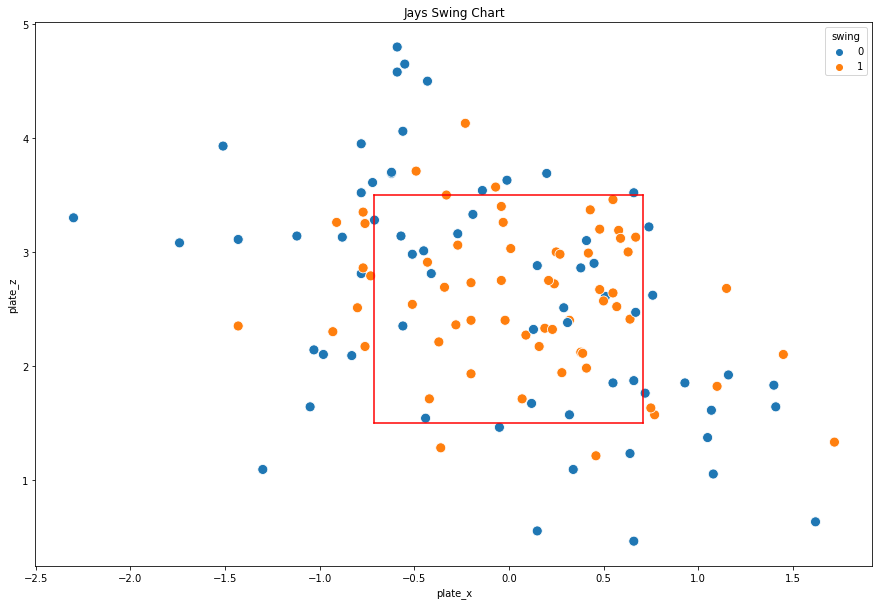

```python
#Plot the position of the pitch when it crosses home plate, along with whether the batter swung at the pitch
plt.figure(figsize=(15,10))
sns.scatterplot(x = jays.plate_x, y = jays.plate_z, hue = jays.swing, s = 100)

#Add the rough strike box (note: Original strike box coordinates will change depending on the height of the player at bat)
plt.plot([-0.71, 0.71], [1.50, 1.50], color = 'red')
plt.plot([-0.71, 0.71], [3.50, 3.50], color = 'red')
plt.plot([-0.71, -0.71], [1.50, 3.50], color = 'red')
plt.plot([0.71, 0.71], [1.50, 3.50], color = 'red')

plt.title("Jays Swing Chart")
```

The first visualization simply focuses on whether the hitter swung at a pitch, given its horizontal and vertical position when it crossed the plate. As expected, most of the pitches outside the red box (strike zone) are blue, showing that the Blue Jays hitters did not swing at it. However, we do notice 2 regions (bottom right of the plate and near the top left) where Blue Jays hitters swung at pitches outside the strike zone.

#### Visualization 2: Swing chart of each individual Blue Jays Hitter

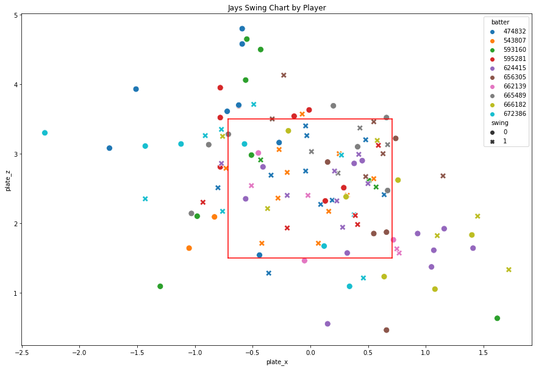

```python
#Plot the position of the pitch when it crosses home plate, along with whether the batter swung at it
plt.figure(figsize=(15,10))
sns.scatterplot(x = jays.plate_x, y = jays.plate_z, style = jays.swing, hue = jays.batter, s = 100)

#Add the rough strike box (note: Original strike box coordinates will change depending on the height of the player at bat)
plt.plot([-0.71, 0.71], [1.50, 1.50], color = 'red')
plt.plot([-0.71, 0.71], [3.50, 3.50], color = 'red')
plt.plot([-0.71, -0.71], [1.50, 3.50], color = 'red')
plt.plot([0.71, 0.71], [1.50, 3.50], color = 'red')

plt.title("Jays Swing Chart by Player")
```

#### Visualization 3 & 4: Swing chart by Twins Pitchers and Pitch Type

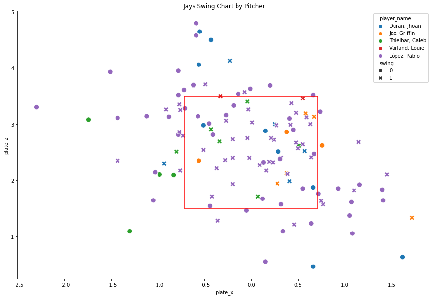

```python
#Plot the position of the pitch when it crosses home plate, along with whether the batter swung at it
plt.figure(figsize=(15,10))
sns.scatterplot(x = jays.plate_x, y = jays.plate_z, style = jays.swing, hue = jays.player_name, s = 100)

#Add the rough strike box (note: Original strike box coordinates will change depending on the height of the player at bat)
plt.plot([-0.71, 0.71], [1.50, 1.50], color = 'red')
plt.plot([-0.71, 0.71], [3.50, 3.50], color = 'red')
plt.plot([-0.71, -0.71], [1.50, 3.50], color = 'red')
plt.plot([0.71, 0.71], [1.50, 3.50], color = 'red')

plt.title("Jays Swing Chart by Pitcher")
```

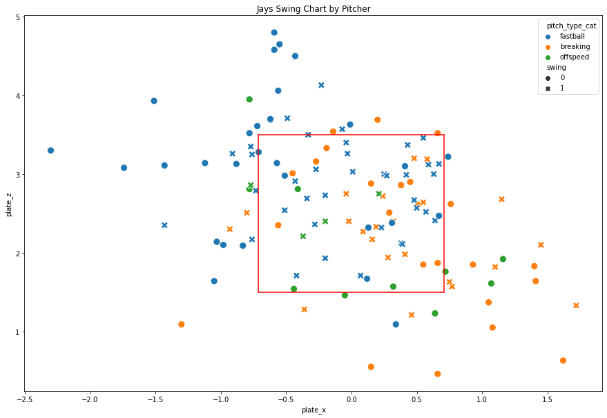

```python
#Plot the position of the pitch when it crosses home plate, along with whether the batter swung at it
plt.figure(figsize=(15,10))
sns.scatterplot(x = jays.plate_x, y = jays.plate_z, style = jays.swing, hue = jays.pitch_type_cat, s = 100)

#Add the rough strike box (note: Original strike box coordinates will change depending on the height of the player at bat)
plt.plot([-0.71, 0.71], [1.50, 1.50], color = 'red')
plt.plot([-0.71, 0.71], [3.50, 3.50], color = 'red')
plt.plot([-0.71, -0.71], [1.50, 3.50], color = 'red')
plt.plot([0.71, 0.71], [1.50, 3.50], color = 'red')

plt.title("Jays Swing Chart by Pitcher")
```

The final swing analysis tries to break down the analysis by the pitcher and pitch type. It must be noted that the starting pitcher is more likely to have more data points than the other pitchers in the bullpen. From this visualization, we see that Pablo Lopez was successful in getting the Blue Jays hitters to swing at outside strike zone pitches with his breaking pitch at the bottom right side, and fastballs to the top left.

```python
#Proportion of Event Type
jays.description.value_counts()/jays.shape[:1]*100
```

```
ball               28.346457
hit_into_play      20.472441
foul               20.472441
called_strike      19.685039
swinging_strike     7.874016
blocked_ball        1.574803
hit_by_pitch        0.787402
foul_tip            0.787402
Name: description, dtype: float64
```

## Minnesota Twins

```python
twins.description.unique()
```

```
array(['called_strike', 'ball', 'swinging_strike', 'foul',
       'hit_into_play', 'swinging_strike_blocked', 'blocked_ball'],
      dtype=object)
```

```python
twins['swing'] = 1
#Update the swing column to 0 for pitches where batter did not swing
twins['swing'] = np.where(twins.description.isin(['ball','blocked_ball','hit_by_pitch','called_strike']), 0, 1)
twins.swing.value_counts()
```

```
0    79
1    59
Name: swing, dtype: int64
```

```python
twins.pitch_type.unique()
```

```
array(['ST', 'FF', 'SI', 'FC', 'CU', 'FS', 'SL'], dtype=object)
```

```python
#The pitchtype currently contains 7 different categories which can be split into 3 major categories.
fastball = ['FF','SI', 'FC']
breaking = ['CU','SL','FS', 'ST']

twins['pitch_type_cat'] = ""

twins['pitch_type_cat'] = np.where(twins['pitch_type'].isin(fastball), 'fastball', twins['pitch_type_cat'])
twins['pitch_type_cat'] = np.where(twins['pitch_type'].isin(breaking), 'breaking', twins['pitch_type_cat'])
twins['pitch_type_cat'] = np.where(twins['pitch_type'].isin(offspeed), 'offspeed', twins['pitch_type_cat'])
```

#### Visualization 1: Swing chart of Minnesota Twins Hitters

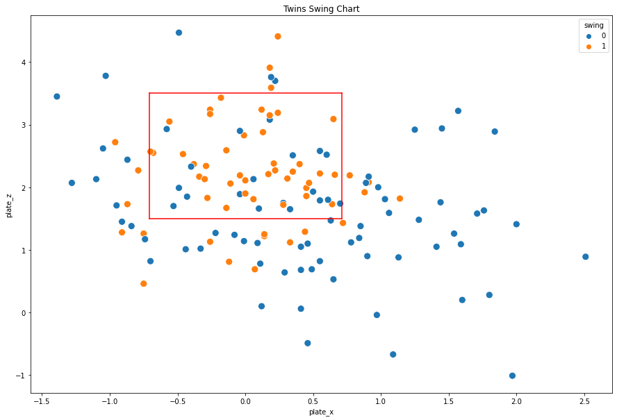

```python
#Plot the position of the pitch when it crosses home plate, along with whether the batter swung at it
plt.figure(figsize=(15,10))
sns.scatterplot(x = twins.plate_x, y = twins.plate_z, hue = twins.swing, s = 100)

#Add the rough strike box (note: Original strike box coordinates will change depending on the height of the player at bat)
plt.plot([-0.71, 0.71], [1.50, 1.50], color = 'red')
plt.plot([-0.71, 0.71], [3.50, 3.50], color = 'red')
plt.plot([-0.71, -0.71], [1.50, 3.50], color = 'red')
plt.plot([0.71, 0.71], [1.50, 3.50], color = 'red')

plt.title("Twins Swing Chart")
```

The very first visualization gives us an idea about the possible strategy that the Blue Jays were trying to use against the Twins. We see a lot of pitches targeted towards the bottom right side of the strike zone. However, as previously mentioned, the Twins hitters showed a lot of plate discipline and did not swing at these pitches.

#### Visualization 2: Swing chart of each individual Twins Hitter

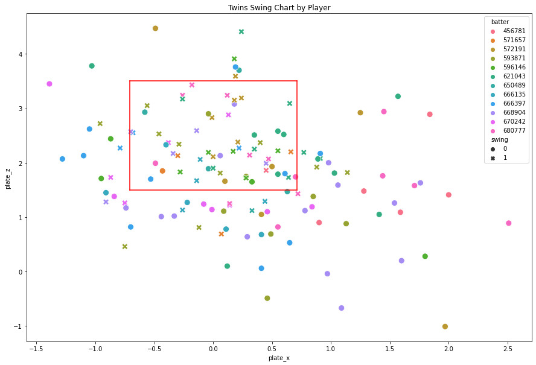

```python
#Plot the position of the pitch when it crosses home plate, along with whether the batter swung at it
plt.figure(figsize=(15,10))
sns.scatterplot(x = twins.plate_x, y = twins.plate_z, style = twins.swing, hue = twins.batter, s = 100)

#Add the rough strike box (note: Original strike box coordinates will change depending on the height of the player at bat)
plt.plot([-0.71, 0.71], [1.50, 1.50], color = 'red')
plt.plot([-0.71, 0.71], [3.50, 3.50], color = 'red')
plt.plot([-0.71, -0.71], [1.50, 3.50], color = 'red')
plt.plot([0.71, 0.71], [1.50, 3.50], color = 'red')

plt.title("Twins Swing Chart by Player")
```

For the Minnesota Twins, we notice that batters 593871 (Jorge Polanco) and 650489 (Willi Castro) have a couple of swings on pitches outside the strike zone. Interestingly we also notice that the Blue Jays pitchers threw a lot of pitches outside the strike zone to player 666397 (Edouard Julien), but he did not swing at them. The pitches outside the strike zone for 668904 (Royce Lewis) can be explained by the Blue Jays' decision to walk him.

#### Visualization 3 & 4: Swing chart by Blue Jays Pitchers and Pitch Type

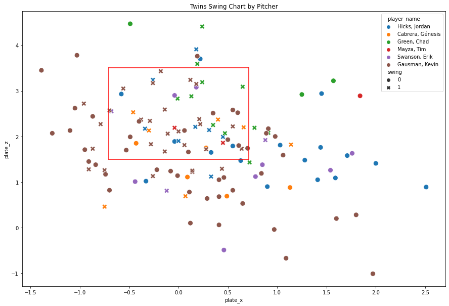

```python
#Plot the position of the pitch when it crosses home plate, along with whether the batter swung at it
plt.figure(figsize=(15,10))
sns.scatterplot(x = twins.plate_x, y = twins.plate_z, style = twins.swing, hue = twins.player_name, s = 100)

#Add the rough strike box (note: Original strike box coordinates will change depending on the height of the player at bat)
plt.plot([-0.71, 0.71], [1.50, 1.50], color = 'red')
plt.plot([-0.71, 0.71], [3.50, 3.50], color = 'red')
plt.plot([-0.71, -0.71], [1.50, 3.50], color = 'red')
plt.plot([0.71, 0.71], [1.50, 3.50], color = 'red')

plt.title("Twins Swing Chart by Pitcher")
```

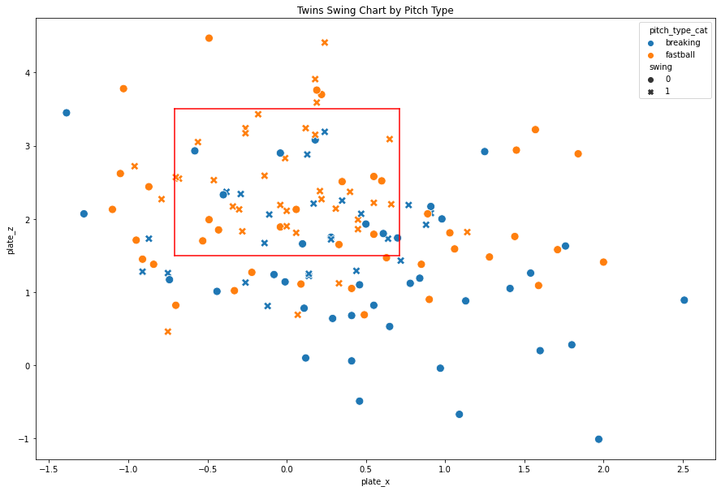

```python
#Plot the position of the pitch when it crosses home plate, along with whether the batter swung at it
plt.figure(figsize=(15,10))
sns.scatterplot(x = twins.plate_x, y = twins.plate_z, style = twins.swing, hue = twins.pitch_type_cat, s = 100)

#Add the rough strike box (note: Original strike box coordinates will change depending on the height of the player at bat)
plt.plot([-0.71, 0.71], [1.50, 1.50], color = 'red')
plt.plot([-0.71, 0.71], [3.50, 3.50], color = 'red')
plt.plot([-0.71, -0.71], [1.50, 3.50], color = 'red')
plt.plot([0.71, 0.71], [1.50, 3.50], color = 'red')

plt.title("Twins Swing Chart by Pitch Type")
```

```python
#Proportion of Event Type
twins.description.value_counts()/twins.shape[:1]*100
```

```
ball                       38.405797
foul                       18.840580
called_strike              16.666667
hit_into_play              13.043478
swinging_strike            10.144928
blocked_ball                2.173913
swinging_strike_blocked     0.724638
Name: description, dtype: float64
```

# Statistical Analysis

The next part of the analysis focuses on the Blue Jays hitters. We try to analyze how the hitters fared against different pitch types and pitch characteristics throughout the game.

```python
jays.head()
```

|  | pitch_type | game_date | release_speed | release_pos_x | release_pos_z | player_name | batter | pitcher | events | description | spin_dir | spin_rate_deprecated | break_angle_deprecated | break_length_deprecated | zone | des | game_type | stand | p_throws | home_team | away_team | type | hit_location | bb_type | balls | strikes | game_year | pfx_x | pfx_z | … |
| --- | --- | --- | --- | --- | --- | --- | --- | --- | --- | --- | --- | --- | --- | --- | --- | --- | --- | --- | --- | --- | --- | --- | --- | --- | --- | --- | --- | --- | --- | --- |
| 80 | FF | 2023-10-03 | 100.9 | -2.12 | 6.1 | Duran, Jhoan | 543807 | 661395 | field_out | hit_into_play | <NA> | <NA> | <NA> | <NA> | 5 | George Springer grounds out sharply, first bas... | F | R | R | MIN | TOR | X | 3 | ground_ball | 0 | 0 | 2023 | -0.94 | 0.76 | … |
| 81 | FF | 2023-10-03 | 102.5 | -2.02 | 6.02 | Duran, Jhoan | 593160 | 661395 | walk | ball | <NA> | <NA> | <NA> | <NA> | 11 | Whit Merrifield walks. | F | R | R | MIN | TOR | B | <NA> | NaN | 3 | 2 | 2023 | -1.0 | 1.05 | … |
| 84 | CU | 2023-10-03 | 89.7 | -2.06 | 5.91 | Duran, Jhoan | 593160 | 661395 | NaN | ball | <NA> | <NA> | <NA> | <NA> | 14 | Whit Merrifield walks. | F | R | R | MIN | TOR | B | <NA> | NaN | 2 | 2 | 2023 | 0.27 | -0.62 | … |
| 86 | FF | 2023-10-03 | 102.0 | -1.77 | 6.04 | Duran, Jhoan | 593160 | 661395 | NaN | ball | <NA> | <NA> | <NA> | <NA> | 11 | Whit Merrifield walks. | F | R | R | MIN | TOR | B | <NA> | NaN | 1 | 2 | 2023 | -0.97 | 1.04 | … |
| 88 | FF | 2023-10-03 | 101.8 | -1.93 | 5.96 | Duran, Jhoan | 593160 | 661395 | NaN | foul | <NA> | <NA> | <NA> | <NA> | 6 | Whit Merrifield walks. | F | R | R | MIN | TOR | S | <NA> | NaN | 1 | 1 | 2023 | -0.92 | 1.17 | … |

```python
#Create a new column that tells is a given pitch resulted in a strike
jays['strike'] = np.where(jays.description.isin(["called_strike", "swinging_strike"]), 1, 0)
jays.strike.value_counts()
```

```
0    92
1    35
Name: strike, dtype: int64
```

### Analysis 1: Pitch Type vs. Strikes

```python
#Pitches faced by the Blue Jays hitters
print("Pitches Thrown:")
print(jays.groupby(['pitch_name'])['pitch_name'].count())

#Count of Strikes by Pitch type
print("\n")
print("Strikes per Pitch Type:")
print(jays.groupby(['pitch_name'])['strike'].sum())

#Average Strikes by Pitch type
print("\n")
print("Avg. Strikes per Pitch Type:")
print(jays.groupby(['pitch_name'])['strike'].mean())
```

```
Pitches Thrown:
pitch_name
4-Seam Fastball    57
Changeup           14
Curveball           9
Sinker             10
Sweeper            37
Name: pitch_name, dtype: int64


Strikes per Pitch Type:
pitch_name
4-Seam Fastball    10
Changeup            5
Curveball           5
Sinker              2
Sweeper            13
Name: strike, dtype: int32


Avg. Strikes per Pitch Type:
pitch_name
4-Seam Fastball    0.175439
Changeup           0.357143
Curveball          0.555556
Sinker             0.200000
Sweeper            0.351351
Name: strike, dtype: float64
```

First, we look at:

1. Total count of each pitch type faced by the Blue Jays hitters
2. Total strikes per pitch type
3. Average strikes per pitch type

From the results, we see that the Twins pitchers threw a lot of Fastballs and Sweepers to the Blue Jays hitters. Unsurprisingly, these pitches also resulted in the most strikes with 28.6% of the strikes coming from Fastballs and 37.1% coming from Sweepers. However, it is also interesting to note that the Twins pitchers used their variations really well because even though the number of curveballs thrown was the lowest, it had the highest efficiency in getting strikes (more than 50%).

### Analysis 2: Pitch Type vs. Strikes per Hitter

```python
#Pitches faced by each individual Blue Jays hitters
pitches_faced = jays.groupby(['batter','pitch_name'])['pitch_type'].count().reset_index()
#print("Pitch Type per Batter:")
#print(jays.groupby(['batter','pitch_name'])['pitch_name'].count())


#Count of Strikes by Pitch type for each individual Blue Jays hitter
pitches_strikes = jays.groupby(['batter','pitch_name'])['strike'].sum().reset_index()
#print("Strike per Pitch Type per Batter:")
#print(jays.groupby(['batter','pitch_name'])['strike'].sum())
```

```python
#Join the 2 dataframes created above
batter_profile = pd.merge(left = pitches_faced, right = pitches_strikes, how = 'left', on = ['batter', 'pitch_name'])
batter_profile.rename(columns={"pitch_type":"pitches_faced"}, inplace=True)
batter_profile.head()
```

|  | batter | pitch_name | pitches_faced | strike |
| --- | --- | --- | --- | --- |
| 0 | 474832 | 4-Seam Fastball | 10 | 1 |
| 1 | 474832 | Changeup | 1 | 1 |
| 2 | 474832 | Curveball | 0 | 0 |
| 3 | 474832 | Sinker | 0 | 0 |
| 4 | 474832 | Sweeper | 7 | 2 |

```python
batter_profile.to_csv('batter_profile.csv', index=False)
```

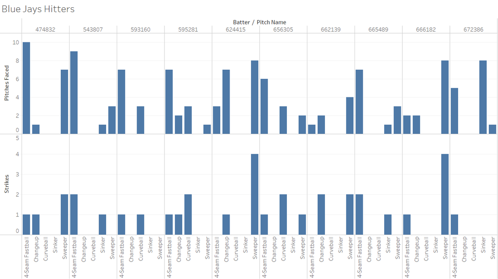

Next, we look at the pitches breakdown for each individual batter. The chart above was created with Tableau, and we can see that the Twins had a different strategy for different Blue Jays hitters. For players 543807 (George Springer) and 595281 (Kevin Kiermaier), a large proportion of the pitches were 4-seam fastballs. As opposed to this, most of the pitches thrown to player 624415 (Cavin Biggio) were Changeup or Sweeper while the majority of pitches to player 666182 (Bo Bichette) were Sweeper.

We can also see that these strategies and variations have worked really well for the Twins, as they got 4 strikes from Sweeper pitches on both Biggio and Bichette. Player 672386 (Kirk) on the other hand seems to have at least dealt with the variation well in terms of strikes. Despite being targeted by a lot of Sinkers, he did not give away a single strike on this kind of pitch.

### Analysis 3: Pitch Characteristics by Strike

```python
jays.groupby(['pitch_name','strike'])['release_speed', 'pfx_x', 'pfx_z', 'vx0', 'vy0', 'vz0', 'release_spin_rate'].mean()
```

| pitch_name | strike | release_speed | pfx_x | pfx_z | vx0 | vy0 | vz0 | release_spin_rate |
| --- | --- | --- | --- | --- | --- | --- | --- | --- |
| 4-Seam Fastball | 0 | 96.278723 | -0.272979 | 1.194681 | 4.012131 | -140.209964 | -4.042381 | 2292.489362 |
|  | 1 | 97.16 | -0.436 | 1.149 | 5.113586 | -141.464999 | -4.960097 | 2256.2 |
| Changeup | 0 | 89.322222 | -1.12 | 0.554444 | 7.492033 | -129.962192 | -3.654835 | 2142.777778 |
|  | 1 | 88.8 | -1.092 | 0.426 | 6.63687 | -129.22122 | -3.656962 | 2115.4 |
| Curveball | 0 | 84.875 | 0.0225 | -0.8225 | 3.412057 | -123.549344 | -3.560966 | 2667.0 |
|  | 1 | 85.38 | 0.086 | -0.75 | 4.350264 | -124.419801 | -0.971285 | 2659.0 |
| Sinker | 0 | 95.725 | -1.06125 | 0.6425 | 4.907954 | -139.377957 | -4.450795 | 2211.375 |
|  | 1 | 96.65 | -1.075 | 0.705 | 5.084094 | -140.633945 | -6.194728 | 2227.0 |
| Sweeper | 0 | 84.908333 | 1.083333 | -0.273333 | 3.595896 | -123.701217 | -0.820673 | 2517.041667 |
|  | 1 | 86.684615 | 1.229231 | -0.206154 | 1.978873 | -126.354951 | -0.821213 | 2726.846154 |

For the final analysis, we try to analyze whether the characteristics of the particular pitch had an impact on deciding whether it resulted in a strike. For this, we look at data such as:

1. release_speed: out of hand pitch velocity
2. pfx_x, pfx_z: horizontal and vertical movement of the pitch
3. vx0, vy0, vz0: the velocity of the pitch in x,y and z dimension at y = 50 feet
4. release_spin_rate: spin rate of the pitch

While for most of the characteristics, we do not see a major difference between pitches that resulted in a strike and those that did not, we do notice that the release spin rate of the 4-Seam Fastball and Changeup is lower on average for pitches that resulted in strikes. Similarly, the Blue Jays seem to have higher average strikes on Curveballs that have a lower velocity in the z-dimension or Sweeper that have a lower velocity in the x-dimension.

This analysis can be extended to individual players over the entire season, to further understand the characteristics of the pitches that lead to higher average strikeouts for the batter.

The goal of this study was to statistically analyze and visualize the match between Toronto Blue Jays and Minnesota Twins. From our analysis, we were able to identify certain important takeaways from the game, including the pitch discipline shown by the Minnesota Twins hitters and the pitch type and characteristics of pitches that the Blue Jays hitters struggled with.